# Your Digest for Tuesday, Apr 09, 2024 11:59 PM

```
- One cause is **HHM** - i.e hypercalcemia associated with Parathyroid hormone related protein **(PTHrP)** . HHM =  **humoral hypercalcemia of malignancy** (HHM). It is also seen in breast, renal, MM.
- **Squamous cells** is the *commonest subtype* causing this.
```

> [!TIP] Mnemonic  
> Tuberculoid : no hair, no water, no sensation, no pigment.  
> Lepromatous : late sensory impairment and sweating.

[output not shown]

> Can occur even before commencement of antibiotic treatment.  
> Can occur **within 3 years of the disease**. Beyond 3 years, it's unlikely to be a lepra reaction.
- Type 1 reactions **result from the activation of cell immunity**. [Source](https://www.google.com/search?client=firefox-b-lm&q=type+1+lepra+reaction)
- Type 1 lepra reactions typically affect the *skin and nerves*, and there are **no systemic symptoms**. The reaction is classified as mild or severe.
  - **Mild type 1 reactions** cause **Induration, swelling or erythema of previous lesions**. There is *no neuritis in **mild** type 1 reactions*.
  - However, **severe type 1 reactions** cause **neuritis** and **skin ulceration**.
  - Can cause **irreversible** nerve damage (foot drop!) within **24 hours**; prompt treatment with **steroids** prevents this.
- Multidrug therapy should be started in a patient *presenting with a lepra reaction* or continued in someone who develops the reaction while on treatment.
- Occurs in *Lepromatous* or *Borderline lepromatous* disease. It's a type **3 hypersensitivity reaction.**
- Type 2 lepra reactions have become rare since the introduction of *clofazimine* treatment. (**Start clofazimine** if not already started if Type 2 reaction occurs)
- *Biopsy of lesions will show polymorphs* -> **diagnostic of type 2 reactions**. (polymorphs not present in other lepromatous lesions). **Biopsy is essential** for diagnosis.
- *Last for a few days*; new crops of lesions may appear.
- **Systemic involvement +++**
  - High *fever*, fatigue.
- *Lucio phenomenon*: very rare; occurs in Mexicans. Necrotising punched punched out ulcers. Can be **life threatening**.  
  ⭐

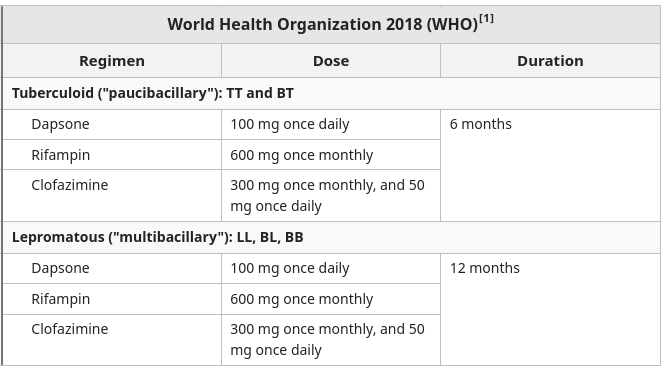

```
+ *Ix* - Patient has *Elevated PTH, Elevated Ca2+ and low PO4* and is **asymptomatic**. No need for further evaluation
```

*Adverse drug **event***: any unexpected or inappropirate occurence that occurs *during **drug administration.*** *Does not necessarily have a causal relationship* to the drug administration.  
| Type | Description | Comments | Example |  
| ------ | ------------------------------- | ----------------------------------------------- | ------------------------------------------------------ |  
| Type A | Augmented - Dose dependent | Can occur at normal or abnormal doses | Serotonin syndrome, bleeding with heparin etc. |  
| C | Chronic - dose and time related | Occurs due to dose accumulation | Adrenal suppresion with corticosteroids |  
| D | Delayed - time related | Due prolonged use without dose accumulation | tardive dyskinseia with atypical antipsychotics |  
| E | End of use | Adverser events on withdrawal | Opiate withdrawal, rebound hypertension with clonidine |  
| F | Failure | Undesirable reduction in drug efficacy | Like drug efficacy reduced by dialysis |

- Increased risk of C. difficile infection
- Acute interstitial nephritis.
- Hypomagnesaemia -> can present with long QT and Torsa de potes.
- Increased fracture risk - PP induced hypochlorhydria can increase osteoclastic activity. [[Hormone Physiology#Regulation of bone formation and resorption]]

MS is short for "*Multiple cerebro-spinal sclerosis*".

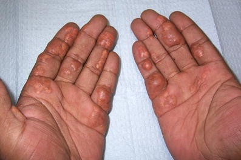

   1. Tendon xanthomas are pathognomonic of *familial hypercholesterolaemia*.  
   3. *Poor response to statins*.  
   4. *Liver transplantation* can normalize lipid levels. (?introduces hepatocytes with functioning LDL receptors)  
   | mainly ⬆ cholesterol | Mainly ⬆TGL |  
   | :---------------------------------------------: | :--------------------------------------------------------------: |  
   | *Disease which have 'O'* | *Mnemonic: ABCDE_GH* |  
   | Nephr*o*tic syndrome | **Alcohol** |  
   | Hyp*o*thyroidism | Beta blockers (*non selective ones* but not carvedilol) |  
   | Ch*o*lestasis | CKD |  
   | *O*CP | Diabetes and Diuretics (*Thiazides*),  
   Diet ( ⬆refined carbs) |  
   | "*O*verweight": Both weight *gain* & *Anorexia* | Estrogen (unopposed) |  
   | | Gammaglobulinopathy |  
   | Hypothyroidism is common to both | Hepatic disease, *hypothyroidism*, HIV |  
   | | Pregnancy (*G*estation), PCOS, |  
   | Glucocorticoids | Glucocorticoids |

> [!TIP] Mnemonic: *Fi*vehundred - *Fi*brates

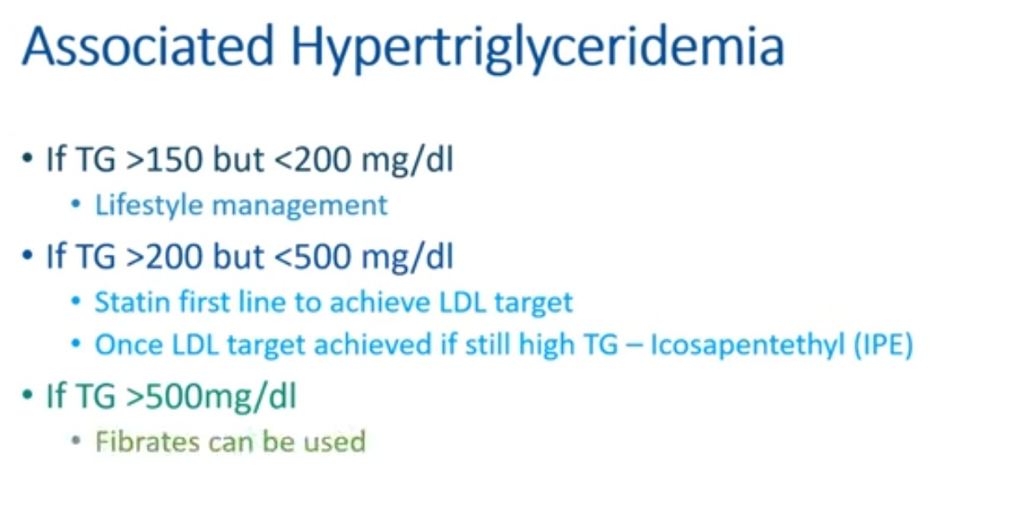

> [!INFO] **Icosapent ethyl**  
> An omega-3 fatty acid, which is also found in fish oil.  
> It is indicated as an adjunct to maximally tolerated statin therapy. [Source](https://www.ncbi.nlm.nih.gov/pmc/articles/PMC10184960/)
> - I.e Indications for high intensity statin treatment are if the patient has previously has had or is having ASCVD.
>   - In which cause, lower LDL to about half the normal values. (100/2 ≈ 55)

#### ⭐Fibrates

- *Increase Lipoprotein lipase activity* -> **reduce TGLs and increase clearance of VLDL**.
- Increase HDL
- SE: *myositis*, nausea, *reversible increase in creatinine*.
- **DO NOT combine ⭐gemfibrozil with statins**
  - **liver enzyme elevation** - *true hepatotoxicity, liver failure are very rare*.
    - Rhabdomyolysis / myositis / myopathy is a known side effect (but rare)
  - They can cause *new onset diabetes.*

[figure not shown]

- Novel class of lipid lowering drug.
- Blocks intestinal absorption of cholesterol by blocking **NPC1L1** sterol transporter.
  - Mnemonic: NP*CILI* looks like **vili**.
- *Can be combined* with statins and PCSK9 inhibitors.
- Can be used as *monotherapy*
- Does not inhibit hepatic cholesterol synthesis or reduce biliary excretion of cholesterol.
- **Can be coadministered** with fenofibrate or HMG-CoA reductase inhibitors, but the recommendation is to dose it at least 2 hours before or 4 hours after taking bile acid sequestrants.
- If **LDL > 190** and familia hypercholesterolaemia has been exluded (which must be managed as it's own entity), **start high dose** (Atorvastatin 40) statin therapy.

## 11: Renal physiology in pregnancy

Source

- the eGFR doesn't work in pregnancy because creatinine is not in steady state.
  - 24 hour Creatinine clearance is the preferred method of calculating GFR in pregnancy.
- the GFR actually increases by 50% !
- Pregnancy is a volume expanded state associated with increased total body sodium.
- Pregnancy is a vasodilated state (mediated by decreased response to angiotensin II)

```
- ⭐ In MesPGN, Isolated haematuria -> *very benign course*;
```

```
- Weakness with monoparesis or hemiparesis, sometimes bilateral is the *most frequent focal deficit in CVT*.
```

> 1. CADASIL -
> - CADASIL (also known as cerebral autosomal dominant arteriopathy with subcortical infarcts and leukoencephalopathy)

# PRES syndrome

Posterior reversible Encephalopathy Syndrome.

- Subacute (days) onset of visual disturbances. seizures, altered mentation, headaches.
- White matter oedema in posterior cerebrum.
- Changes are reversible (most often)

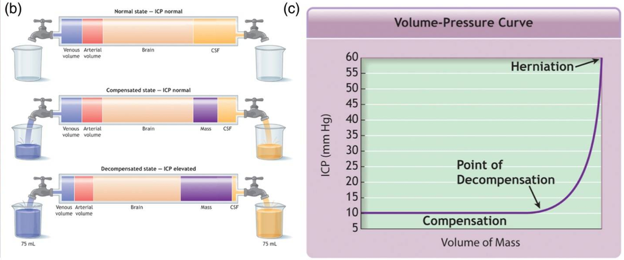

> 3. The *venous drainage of the brain does not have valves* to the **JVP is directly transmitted** to the cerebral veins.  
>    Interpretation of forrest plot:
> - Vertical solid line - line of no effect.
> - Size of squares -> power of the study and therefore, effect on the metaanalysis result.
> - Horizontal lines - confidence interval for a given study.

> #2017SBR-APR/Q09
> 1. Lyme disease <
> 2. Guillain Barre syndrome
> 3. Bell's Palsy (bialteral) <- *the most common cause of B/L facial palsy* (but is a diagnosis of exclusion)
> 4. [[Tuberculosis]] / Tumours (see 7)
> 5. [[Sarcoidosis]]
> 6. Bilateral acoustic neuroma (*NF type 2*) or *pontine tumours affecting both cranial nerve nuclei*.

> However, in *MR and AR*, murmur loudness does correlate with severity.

[output not shown]

#### Presenting complaints of CKD:

```
- *Hypertension is very common by 30-40 years*. (Even when renal function is normal)
```

- All patients with PCKD have a *mild concentrating defect* (one of the **earliest features of the diseaes** ) causing them to develop *thirst*, **polyuria**, *frequency and nocturia*.) - mechanism not known.
- Diagnosis is **primarily** by **imaging**. (Genetic testing usually not required).
- All patients will develop renal cysts.
- Is inherently unstable -> either terminates spontaneously or degenerates to VF
- Can occur in **hypokalemia**
- *Group Ia antiarrthmics which prolong QT should never be used!* (basically, disopyramide is contraindicated) [[Cardiology MCQ discussion#Antiarrhythmic drugs|Antiarrhtymics]]  
  | **Congenital** | **Drugs** | **Other** |  
  | ------------------------------------------------------------------------------------------------------------------------------------------------ | ---------------------------------------------------------------------------------------------------------------------------------------------------------------------------------------------------------------------------------------------------------- | ------------------------------------------------------------------------------------------------------------------------------------------------------------ |  
  | - Jervell-Lange-Nielsen syndrome (includes **deafness** and is due to an abnormal potassium channel)  
  - Romano-Ward syndrome (**no deafness**) | - amiodarone, sotalol, class 1a antiarrhythmic drugs  
  - *tricyclic* antidepressants, *fluoxetine*  
  - chloroquine  
  - terfenadine  
  - **erythromycin** and *fluoroquinolones*  
  - Haloperidol and other antipsychotics  
  - ondansetron, sumatriptan | - electrolyte: hypocalcaemia, hypokalaemia, hypomagnesaemia  
  - acute myocardial infarction  
  - myocarditis  
  - hypothermia  
  - subarachnoid haemorrhage |  
  | | [Source](https://www.ncbi.nlm.nih.gov/books/NBK534864/) | |
- Tick borne - **ixodes** ticks

Side effects

- Electrical stuff:
  - lower **seizure threshold** in patients with epilepsy
  - *lengthens QT interval*
- **Avoid in pregnancy** and breast feeding.
- Contraindicated in *G6PD deficiency*.
- **0 order / zero order kinetics at *therapeutic concentrations*** (saturation kinetics)
  - **Uraemia**-> *uraemic toxins displace phenytoin from Albumin* -> higher plasma concentration of phenytoin --> toxicity.
- Phenytoin elimination is only 5% renal; Majority of elimination is by the P450 system. [Source](https://www.google.com/search?client=firefox-b-d&q=phenytoin+elimination)
- Potent **Enzyme inducer**.
- **Valproate displaces phenytoin** from bound proteins -> increased risk of toxicity.

### **Area under the curve** (AUC)

- AUC is directly proportional to the amount of drug absorbed after administration (from any given route)

$$
AUC=\frac{{Dose}\times{Bioavailability}}{Total\space Clearance}
$$

- Therefore, the reporting unit for AUC is mg.h/L (milligram hours per liter)[Source](https://pharmaeducation.net/auc-in-pharmacokinetics/)
- For drugs with *liner* (aka First order) kinetics, the AUC **is not affected by doring regime** (provided the same total amount of drug is administered)
  - i.e 60mg/m2 stat dose of doxorubicin will have the same AUC as 3 doses of 20mg/m2 8 hours apart or a 60mg infusion given continuously.
  - Therefore, the **AUC for a 60mg dose can be used to estimate the AUC for a different regime**. [Source](https://www.ncbi.nlm.nih.gov/books/NBK12815/)
- For an IV drug, AUC is given by

$$
\Large{AUC = \frac{C_0}{λ}}
$$

λ = **elimination rate constant** see [[#The elimination constant]]  
[Source](https://sepia2.unil.ch/pharmacology/parameters/areaunderthecurve/)

#2022BSQ/Q17

> [!INFO] It's not a large initial dose; it's small maintenance doses.  
> How to intuitively think about a loading dose:  
> If a drug has a slow T1/2, that means it's eliminated slowly; So why would we give a large initial dose?  
> It makes sense if you think about it the other way around;
> - With a loading dose, we're giving a "*normal*" dose first and then following it up with low doses due to slow elimination.
> - For bolus doses, maintenance dose = Desired concentration x Clearance x dosing interval / Bioavailability

> [!INFO]  
> Zero order = saturation  
> First order = non saturation = *linear* kinetics.  
> "linear" because rate of elimination is directly proportional to concentration.

# Effects of pregnancy of drug pharmacokinetics

[Source](https://derangedphysiology.com/main/cicm-primary-exam/required-reading/variability-drug-response/Chapter%20241/changes-drug-response-during-pregnancy)

- Slow gastric emptying and *increased* gastric pH **reduce** absorption.
- Slower intestinal transit time **increases** absorption.
- Net effect: for most drugs absorption is unchanged.
- *Progesterone* induces liver enzymes.
- Hepatobiliary clearance is reduced due to the cholestatic effects of *oestrogen*.
- Increased renal elimination due to increased GFR but renal reabosorption may increase for some drugs.

See [Source](https://uploads-ssl.webflow.com/5e19f85d3feecdf9ff105b40/5e5f48fd7b704ff99bd664bf_Ceylon%20College%20of%20Physicians%20asthma%2013%20June.pdf)